[Math 441 portfolio](http://rctcwyvrn.github.io/optimization_portfolio)

# Learning portfolio: Alternative nearest neighbours algorithms

# Learning portfolio: Alternative nearest neighbours algorithms

During class we discussed a basic idea of nearest neighbours: each step simply introduce the nearest neighbour as the next node in the path. I had an idea for an addition to the method that I'm curious to see if they'll make a difference at all

Starting with the code from lecture

```python
import numpy as np
import scipy.linalg as la
import matplotlib.pyplot as plt
from itertools import permutations

def cost_matrix(V):
    n = V.shape[0]
    C = np.zeros((n,n))
    for i in range(1,n):
        for j in range(0,i):
            C[i,j] = la.norm(V[i,:] - V[j,:])
            C[j,i] = C[i,j]
    return C

def tour_cost(C,tour):
    n = len(tour)
    cost = 0
    for i in range(n-1):
        cost += C[tour[i],tour[i+1]]
    cost += C[tour[-1],tour[0]]
    return cost

def brute_force(V):
    n = V.shape[0]
    tours = permutations(range(n))
    C = cost_matrix(V)
    optimal_cost = None
    for tour in tours:
        cost = tour_cost(C,tour)
        if optimal_cost is None or cost < optimal_cost:
            optimal_cost = cost
            optimal_tour = np.array(tour)
    return optimal_tour,optimal_cost

def plot_tour(V,tour, color='b'):
    n = len(tour)
    for i in range(n-1):
        plt.plot([V[tour[i],0],V[tour[i+1],0]],[V[tour[i],1],V[tour[i+1],1]],color)
    plt.plot([V[tour[-1],0],V[tour[0],0]],[V[tour[-1],1],V[tour[0],1]],color)
    plt.scatter(V[:,0],V[:,1],s=10)
    plt.show()

def random_tour(n):
    return np.random.rand(n,2)

def nearest_neighbor(V,start=0):
    n = V.shape[0]
    C = cost_matrix(V)
    tour = [start]
    nodes = list(range(n))
    nodes.remove(start)
    for i in range(1,n):
        next_i = np.argmin(C[tour[-1],nodes])
        next_node = nodes[next_i]
        tour.append(next_node)
        nodes.pop(next_i)
    cost = tour_cost(C,tour)
    return tour,cost
```

```
9.488932288398855
```

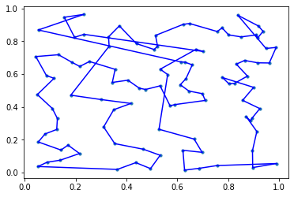

```python
V = random_tour(100)
tour,cost = nearest_neighbor(V,start=11)
print(cost)
plot_tour(V,tour)
```

In this example with many nodes we see one of the major flaws of nearest neighbours, that it only has local reasoning. It fails to consider how it's choice might affect choices later down in the path, resulting in some very inefficient pathing (for example that massive diagonal line running down the center)

My idea for fixing this is: employ a similar idea to chess algorithms

In chess, there's the idea of a minimax algorithm, one where the best move is not the one that results in the best position, but one where the opponent's best move after that move results in the best possible position.

We can implement a similar idea in nearest neighbours by not taking the closest neighbour, but rather the pair of neighbours with the shortest total distance for that pair. Or the triplet etc etc.

The plan to implement this is to perform a lookahead to all possible choices of depth $n$ we can make from the current tour, and then picking the triplet with the smallest possible total distance.

```python
def lookahead_nearest_neighbor(V,start=0, lookahead=1,closest=True):
    n = V.shape[0]
    C = cost_matrix(V)

    def lookahead_get_choices(current_tour, available_nodes, peek):
        if peek == 0:
            t = pick_next_tour_location(current_tour, available_nodes)
            return [[tour_cost(C, t[0]), t]]
        else:
            choices = []
            for node_i, node in enumerate(available_nodes):
                temp = list(available_nodes)
                temp.pop(node_i)
                choices += lookahead_get_choices(current_tour + [node], temp, peek-1)
            return choices

    def lookahead_pick(current_tour, available_nodes):
        peek = min(len(available_nodes), lookahead)
        choices = lookahead_get_choices(current_tour, available_nodes, peek)
        # print("current", current_tour)
        # print("choices", choices)
        sorted_choices = sorted(choices, key=lambda x: x[0])
        if closest:
            best = sorted_choices[0]
            return best[1][0], best[1][1]
        else:
            best = sorted_choices[-1]
            return best[1][0], best[1][1]

    def pick_next_tour_location(current_tour, available_nodes):
        if len(available_nodes) == 0:
            return (current_tour, [])
        next_i = np.argmin(C[current_tour[-1],available_nodes])
        next_node = available_nodes[next_i]
        temp = list(available_nodes)
        temp.pop(next_i)
        return (current_tour + [next_node], temp)

    def build_tour(current_tour, available_nodes):
        if len(available_nodes) == 1:
            return current_tour + [available_nodes[0]]
        else:
            next_tour, new_avail = lookahead_pick(current_tour, available_nodes)
            return build_tour(next_tour, new_avail)

    tour = [start]
    nodes = list(range(n))
    nodes.remove(start)
    tour = build_tour(tour, nodes)
    cost = tour_cost(C,tour)
    return tour,cost
```

```
4.065308328145557
```

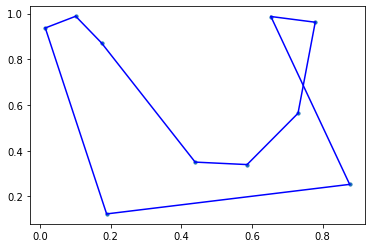

```python
V = random_tour(10)
lookahead_tour, lookahead_cost = lookahead_nearest_neighbor(V,start=0, lookahead=1)
print(lookahead_cost)
plot_tour(V, lookahead_tour)
```

```
9.531959100543856
```

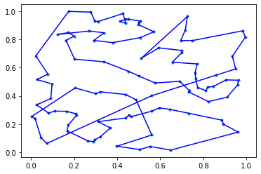

```
9.531959100543856
```

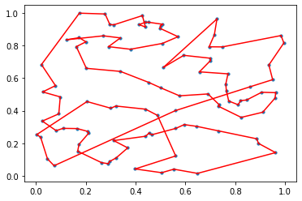

```python
# zero lookahead, should be identical
V = random_tour(100)
lookahead_tour, lookahead_cost = lookahead_nearest_neighbor(V,start=0, lookahead=0)
print(lookahead_cost)
plot_tour(V, lookahead_tour)

normal_tour, normal_cost = nearest_neighbor(V,start=0)
print(normal_cost)
plot_tour(V, normal_tour, color='r')
```

```
11.401142274319987
```

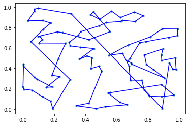

```
9.59146287286695
```

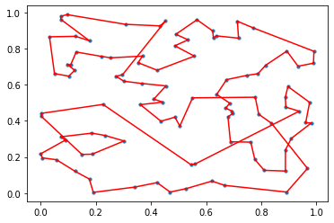

```python
# one lookahead
V = random_tour(100)
lookahead_tour, lookahead_cost = lookahead_nearest_neighbor(V,start=0, lookahead=1)
print(lookahead_cost)
plot_tour(V, lookahead_tour)

normal_tour, normal_cost = nearest_neighbor(V,start=0)
print(normal_cost)
plot_tour(V, normal_tour, color='r')
```

```
9.139110745144565
```

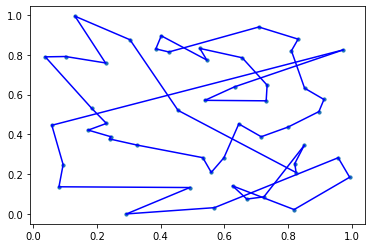

```
7.474116228776019
```

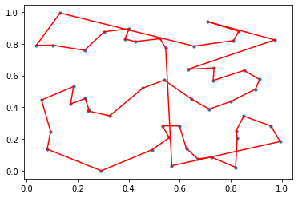

```python
# 2 lookahead
V = random_tour(50)
lookahead_tour, lookahead_cost = lookahead_nearest_neighbor(V,start=0, lookahead=2)
print(lookahead_cost)
plot_tour(V, lookahead_tour)

normal_tour, normal_cost = nearest_neighbor(V,start=0)
print(normal_cost)
plot_tour(V, normal_tour, color='r')
```

```
9.537010194827669
```

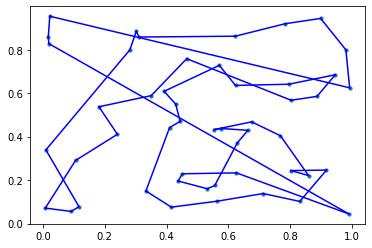

```
7.467120267083056
```

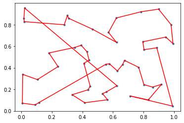

```python
# 3 lookahead
V = random_tour(50)
lookahead_tour, lookahead_cost = lookahead_nearest_neighbor(V,start=0, lookahead=3)
print(lookahead_cost)
plot_tour(V, lookahead_tour)

normal_tour, normal_cost = nearest_neighbor(V,start=0)
print(normal_cost)
plot_tour(V, normal_tour, color='r')
```

## Conclusion

Turns out it doesn't actually help at all...

I wonder why?

I honestly don't know why. No clue. Maybe it's just because I implemented this thing wrong...my debugging seems to show that it's working correctly though.

I wonder if it's because this method promotes the algorithm into taking a big jump into a bunch of close nodes, taking those close nodes, and then having to jump all the way out again.

## Testing

Can I build an example which shows why this lookahead strategy performs worse?

I wonder if farthest neighbours will work any better

```
23.316235255178988
```

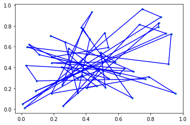

```
6.972273817391359
```

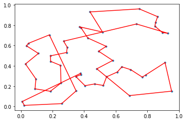

```python
# 2 lookahead
V = random_tour(50)
lookahead_tour, lookahead_cost = lookahead_nearest_neighbor(V,start=0, lookahead=2, closest=False)
print(lookahead_cost)
plot_tour(V, lookahead_tour)

normal_tour, normal_cost = nearest_neighbor(V,start=0)
print(normal_cost)
plot_tour(V, normal_tour, color='r')
```

Ah...

I was vaguely hoping it would form a convex shell like the farthest insertion method, but evidently not.

It's a very pretty spiderweb though